# Multilevel Models- Group 9

Md Emon Parvez

2024-03-21

## Multilevel Models for Big Data: Approaches for Handling Very Large Data Sets

This notebook explores the application of multilevel models to analyze large datasets, focusing on techniques tailored to handle very large data sets. It delves into various approaches for modeling hierarchical structures in data, such as linear mixed-effects models (LMM) and generalized additive models (GAM), and discusses strategies for efficient computation and interpretation. Through practical examples and demonstrations, the notebook showcases methods to address the challenges posed by big data when employing multilevel modeling techniques.

**Note**: It is important to acknowledge that minor discrepancies may exist between the R Markdown (RMD) file and its corresponding HTML output. These discrepancies primarily pertain to the presentation of output numbers, particularly those generated by functions such as `system.time()` which detail user, system, and elapsed times, as well as visualizations. Such discrepancies can arise due to inherent differences in rendering engines, display settings, or output formats between the local R environment where the RMD file is authored and the HTML rendering environment where the output is displayed.

#### What and Why Multilevel or Mixed Model?

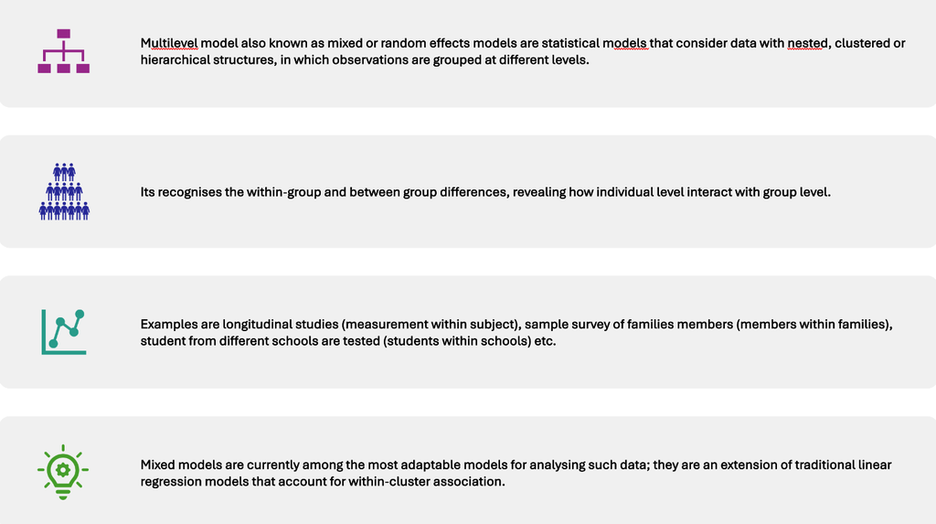

Mixed Models, often denoted as MM, scrutinize the impact of independent factors, whether categorical or numerical, on a dependent variable. These models derive their name from their amalgamation of fixed factors, pertinent to researchers, and random factors, whose effects are less directly relevant. While random effects, can be accommodated, their inclusion is typically restricted to one factor. MM serve as versatile tools, surpassing conventional methods like analysis of variance, and expanding upon the capabilities of linear and logistic regression analyses. They inherently account for variability stemming from a single factor and tolerate missing values within their framework.

**Libraries :**

- **tidyverse:** For data manipulation and visualization.
- **lme4:** For fitting linear mixed-effects models.
- **mgcv:** For fitting generalized additive models.
- **sdamr:** For additional GAM functionality.
- **library(knitr):** For dynamic report generation.
- **mixedup:** For extracting results from mixed models.

```r
# Load necessary libraries
library(tidyverse)   # For data manipulation and visualization
library(lme4)        # For fitting linear mixed-effects models
library(mgcv)        # For fitting generalized additive models
library(sdamr)       # For additional GAM functionality
library(knitr)       # For dynamic report generation
library(mixedup)     # For extracting results from mixed models
```

**Simulated Data:**

This code chunk facilitates the generation of simulated data for illustrative purposes. Initially, the random seed is set to ensure reproducibility. The simulated dataset comprises a substantial sample size (N = 2,000,000), distributed across 2000 groups, each identified by a group identifier (g) to represent the hierarchical structure. Two variables are created: an observation-level continuous variable (x) and a cluster-level categorical variable (b). Parameters for the standard deviation of the random effect (sd_g) and observation (sigma) are specified, followed by the generation of random effects (re) based on the group structure and standard deviation. The linear predictor (lp) is computed using the generated variables and random effects. Subsequently, continuous (y) and binary (y_bin) target variables are generated based on the linear predictor, with added noise. The resulting dataframe (d) encapsulates the simulated data, facilitating the exploration and demonstration of various modeling techniques.

**Properties:**

- Total sample size: 2,000,000
- Number of groups: 2000
- Variables:
  - x: Continuous
  - b: Categorical
  - y: Continuous
  - y_bin: Binary
  - g: Group identifier
- Standard deviation of random effect (sd_g): 0.5
- Standard deviation of observation (sigma): 1
- Hierarchical structure: Groups represented by the group identifier
- Target variables: Continuous (y) and binary (y_bin)
- Purpose: Illustration of modeling techniques with hierarchical data structures and large datasets.

```r
# Set seed for reproducibility
set.seed(12358)

# Generate simulated data
N <- 2e6             # Total sample size
n_groups <- 2000     # Number of groups
g <- rep(1:n_groups, each = N/n_groups)  # Group identifier

# Generate variables
x <- rnorm(N)                              # Observation-level continuous variable
b <- rbinom(n_groups, size = 1, prob = 0.5) # Cluster-level categorical variable
b <- b[g]

# Parameters
sd_g <- 0.5           # Standard deviation for the random effect
sigma <- 1            # Standard deviation for observation

# Generate random effects
re0 <- rnorm(n_groups, sd = sd_g)
re <- re0[g]

# Linear predictor
lp <- 0 + 0.5*x + 0.25*b + re

# Continuous and binary target variables
y <- rnorm(N, mean = lp, sd = sigma)
y_bin <- rbinom(N, size = 1, prob = plogis(lp))

# Create a dataframe
d <- tibble(x, b, y, y_bin, g = factor(g))
head(d)
```

```
## # A tibble: 6 × 5
##        x     b      y y_bin g
##    <dbl> <int>  <dbl> <int> <fct>
## 1 -0.378     0  0.181     1 1
## 2 -0.812     0 -1.09      0 1
## 3  0.218     0  0.292     1 1
## 4  1.53      0 -0.663     0 1
## 5 -1.88      0 -0.772     0 1
## 6 -0.427     0 -1.54      0 1
```

**Visualizing the distribution of the simulated data**

Utilizing histograms for continuous variables (x, y, and b) and a bar plot for the binary variable y_bin,

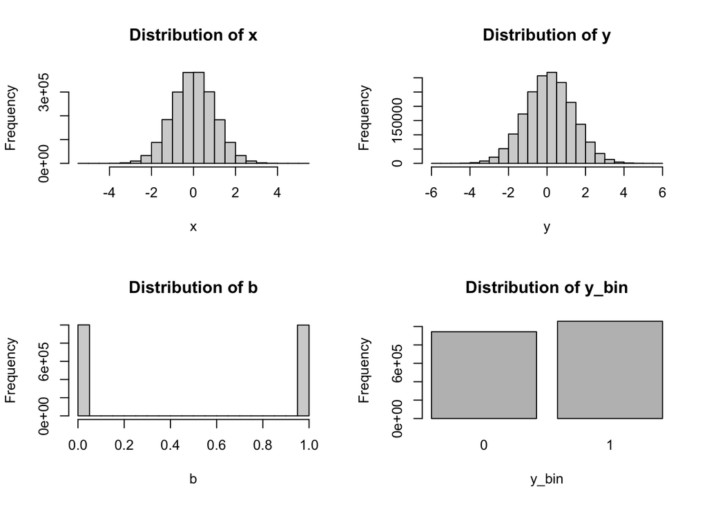

### Linear Mixed-Effects Model (LMM)

The Linear Mixed-Effects Model (LMM) is represented by the formula:

$$Y = X\beta + Zb + \epsilon$$

where:

- $Y$ represents the vector of observed responses (dependent variable).
- $X$ is the design matrix for fixed effects.
- $\beta$ denotes the vector of fixed-effect coefficients.
- $Z$ is the design matrix for random effects.
- $b$ represents the vector of random-effect coefficients.
- $\epsilon$ is the vector of residual errors.

LMMs are employed for analyzing data with hierarchical or nested structures, accommodating both fixed effects (population-level parameters) and random effects (variation at the group level). These models are widely used in various disciplines to account for within-group and between-group variability, particularly in studies involving clustered or longitudinal data.

**Fitting Linear Mixed-Effects Model in simulated data**

Now let’s model a linear mixed-effects model (LMM) using the `lmer` function from the `lme4` package. The model is applied to a continuous outcome variable (`y`) with observation-level continuous predictor (`x`), cluster-level categorical predictor (`b`), and a random intercept term for the group identifier (`g`). The `system.time` function is utilized to measure the computational time required for model fitting. This model is applied to a large dataset consisting of 2 million observations distributed among 2000 groups, allowing for the analysis of hierarchical structures within the data.

```r
system.time({
  mixed_big = lmer(y ~ x + b + (1|g))
})
```

```
##    user  system elapsed
##  10.341   0.859  11.506
```

```r
summary(mixed_big, cor = FALSE)
```

```
## Linear mixed model fit by REML ['lmerMod']
## Formula: y ~ x + b + (1 | g)
##
## REML criterion at convergence: 5689585
##
## Scaled residuals:
##     Min      1Q  Median      3Q     Max
## -5.0311 -0.6740  0.0005  0.6739  5.3570
##
## Random effects:
##  Groups   Name        Variance Std.Dev.
##  g        (Intercept) 0.2568   0.5068
##  Residual             1.0014   1.0007
## Number of obs: 2000000, groups:  g, 2000
##
## Fixed effects:
##             Estimate Std. Error t value
## (Intercept) 0.005957   0.016049   0.371
## x           0.500046   0.000708 706.239
## b           0.243823   0.022708  10.737
```

Overall, the model suggests that the predictor variable ‘x’ has a significant effect on the outcome variable, with an estimated coefficient of 0.500046. Additionally, the categorical variable ‘b’ also has a significant effect on the outcome variable, with an estimated coefficient of 0.243823.

### Generalized Linear Mixed-Effects Model (GLMM)

The Generalized Linear Mixed-Effects Model (GLMM) extends the LMM framework and is expressed by the formula:

$$g(\mu) = X\beta + Zb$$

where:

- $g()$ represents the link function relating the mean of the response variable $\mu$ to the linear predictor.
- $X$, $\beta$, $Z$, and $b$ have the same interpretation as in the LMM.

GLMMs accommodate non-normally distributed response variables and different probability distributions, making them suitable for analyzing binary, count, or categorical outcomes. By incorporating both fixed and random effects, GLMMs provide flexibility in modeling correlated or hierarchical data with non-normal response variables, offering robustness and versatility in various research contexts.

**Fitting Generalized Linear Mixed-Effects Model(GLMM) with glmer in simulated data**

Next, a generalized linear mixed-effects model (GLMM) is fitted using the `glmer` function from the `lme4` package. The model is applied to a binary outcome variable (`y_bin`) with observation-level continuous predictor (`x`), cluster-level categorical predictor (`b`), and a random intercept term for the group identifier (`g`). The `family` argument specifies the binomial distribution for the outcome variable.

```r
system.time({
  mixed_big_glmm = glmer(y_bin ~ x + b + (1|g), family = binomial)
})
```

```
##    user  system elapsed
## 232.666  44.112 311.531
```

```r
summary(mixed_big_glmm)
```

```
## Generalized linear mixed model fit by maximum likelihood (Laplace
##   Approximation) [glmerMod]
##  Family: binomial  ( logit )
## Formula: y_bin ~ x + b + (1 | g)
##
##      AIC      BIC   logLik deviance df.resid
##  2554054  2554104 -1277023  2554046  1999996
##
## Scaled residuals:
##     Min      1Q  Median      3Q     Max
## -5.1255 -0.9175  0.4848  0.8608  4.2161
##
## Random effects:
##  Groups Name        Variance Std.Dev.
##  g      (Intercept) 0.2579   0.5079
## Number of obs: 2000000, groups:  g, 2000
##
## Fixed effects:
##             Estimate Std. Error z value Pr(>|z|)
## (Intercept) 0.006878   0.016168   0.425    0.671
## x           0.499174   0.001581 315.786   <2e-16 ***
## b           0.241952   0.022899  10.566   <2e-16 ***
## ---
## Signif. codes:  0 '***' 0.001 '**' 0.01 '*' 0.05 '.' 0.1 ' ' 1
##
## Correlation of Fixed Effects:
##   (Intr) x
## x  0.000
## b -0.706  0.003
```

**Comparison of Linear Mixed-Effects Model (LMM) and Generalized Linear Mixed-Effects Model (GLMM) for Handling Large Datasets**

In terms of handling large datasets, LMMs are generally more efficient and computationally faster than GLMMs, especially when dealing with continuous outcomes. LMMs are suitable for modeling hierarchical data structures with random effects while maintaining computational efficiency. On the other hand, GLMMs are preferred when dealing with binary or categorical outcomes, as they allow for modeling of the underlying probability distribution directly. However, due to their computational complexity, GLMMs may be less efficient for large datasets compared to LMMs.

Therefore, in scenarios where the outcome variable is continuous and hierarchical data structures need to be accounted for, the LMM approach is preferable for handling large datasets efficiently.

### Exploring Statistical Models on Multilevel Data: Insights from the “metacognition” Dataset

Now, we will use The “metacognition” dataset from the “sdmar” package to explore the behavior of `lmer` and `bam` statistical models on multilevel data structures. This investigation aims to uncover insights into the performance and suitability of these models for analyzing hierarchical data encountered in cognitive experiments and tasks.

**Metacognition Dataset Description:**

The dataset comprises observations from a cognitive psychology experiment, including the following variables:

- **id:** Participant ID
- **age:** Age of the participant
- **sex:** Gender of the participant (female/male)
- **block:** Block number of the trial
- **trial:** Trial number within the block
- **tilt:** Tilt angle of the stimulus (degrees)
- **contrast:** Contrast level of the stimulus
- **correct:** Binary indicator of correct response (0 = incorrect, 1 = correct)
- **visibility:** Visibility level of the stimulus
- **confidence:** Confidence level in the response

The dataset contains a total of 7560 observations. Numeric variables include age, block, trial, tilt, contrast, visibility, confidence, and correct, while sex is a categorical variable.

Summary statistics for the numeric variables are as follows:  
- **age:** Minimum age is 20, maximum age is 30, with a mean of approximately 23.85.  
- **tilt:** Tilt angle ranges from 0 to 90 degrees, with a mean of approximately 44.06 degrees.  
- **contrast:** Contrast level ranges from 0 to 6.9, with a mean of approximately 3.917.  
- **visibility:** Visibility level ranges from 0 to 100, with a mean of approximately 39.202.  
- **confidence:** Confidence level ranges from 0 to 100, with a mean of approximately 58.52.

The majority of participants are female (6048), and the remaining are male (1512). The data are organized into blocks and trials within each block, with varying levels of tilt, contrast, visibility, and confidence. The correct response rate is approximately 77%.

```
##   id age    sex block trial tilt contrast correct visibility confidence
## 1  1  22 female     1     1   90      6.9       1   67.71649   66.92912
## 2  1  22 female     1     2    0      2.2       0   41.73037   34.64408
## 3  1  22 female     1     3    0      5.0       1   70.07858   68.11017
## 4  1  22 female     1     4   90      0.0       1   36.61250   30.70726
## 5  1  22 female     1     5   90      3.9       1   48.02930   48.42298
## 6  1  22 female     1     6    0      0.0       0   47.24193   41.73037
```

```
##        id            age            sex           block          trial
##  1      : 378   Min.   :20.00   female:6048   1      : 840   Min.   : 1.0
##  2      : 378   1st Qu.:21.75   male  :1512   2      : 840   1st Qu.:11.0
##  3      : 378   Median :23.00                 3      : 840   Median :21.5
##  4      : 378   Mean   :23.85                 4      : 840   Mean   :21.5
##  5      : 378   3rd Qu.:26.00                 5      : 840   3rd Qu.:32.0
##  6      : 378   Max.   :30.00                 6      : 840   Max.   :42.0
##  (Other):5292                                 (Other):2520
##       tilt          contrast        correct       visibility
##  Min.   : 0.00   Min.   :0.000   Min.   :0.00   Min.   :  0.000
##  1st Qu.: 0.00   1st Qu.:2.200   1st Qu.:1.00   1st Qu.:  2.362
##  Median : 0.00   Median :4.450   Median :1.00   Median : 34.644
##  Mean   :44.06   Mean   :3.917   Mean   :0.77   Mean   : 39.202
##  3rd Qu.:90.00   3rd Qu.:5.500   3rd Qu.:1.00   3rd Qu.: 66.929
##  Max.   :90.00   Max.   :6.900   Max.   :1.00   Max.   :100.000
##
##    confidence
##  Min.   :  0.00
##  1st Qu.: 16.14
##  Median : 68.11
##  Mean   : 58.52
##  3rd Qu.:100.00
##  Max.   :100.00
##
```

**Checking if any missing values are there in our `metacognition`dataset**

```
##         id        age        sex      block      trial       tilt   contrast
##          0          0          0          0          0          0          0
##    correct visibility confidence
##          0          0          0
```

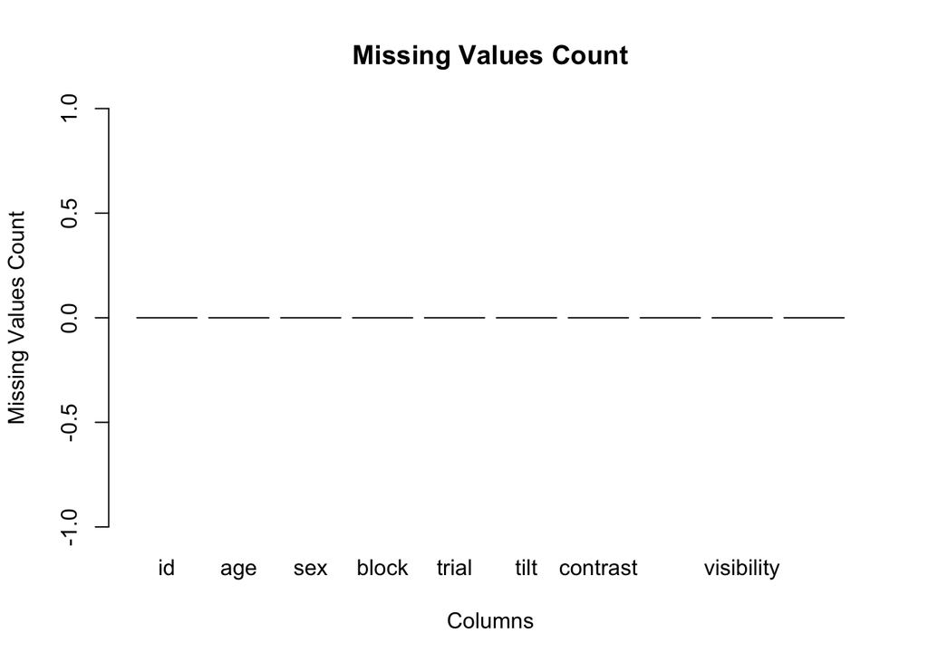

#### Exploring the Influence of Stimulus Visibility on Confidence Levels: Investigating Individual Variations and Gender Differences using `lmer` and `bam` model

**Research Question 1: Model 1**

**“How does the visibility of stimuli influence individuals’ confidence in their responses, considering potential individual variations in response patterns?”**

```r
# Fit linear mixed-effects model
system.time({
  mixed_model1 <- lmer(confidence ~ visibility + (1 | id), data = metacognition)
})
```

```
##    user  system elapsed
##   0.036   0.004   0.043
```

```r
# Summary of the model
summary(mixed_model1)
```

```
## Linear mixed model fit by REML ['lmerMod']
## Formula: confidence ~ visibility + (1 | id)
##    Data: metacognition
##
## REML criterion at convergence: 66953.5
##
## Scaled residuals:
##     Min      1Q  Median      3Q     Max
## -6.1579 -0.5829 -0.0258  0.5958  4.9801
##
## Random effects:
##  Groups   Name        Variance Std.Dev.
##  id       (Intercept) 157.0    12.53
##  Residual             405.4    20.14
## Number of obs: 7560, groups:  id, 20
##
## Fixed effects:
##              Estimate Std. Error t value
## (Intercept) 18.718753   2.826389   6.623
## visibility   1.015233   0.007479 135.736
##
## Correlation of Fixed Effects:
##            (Intr)
## visibility -0.104
```

**Research Question 2: Model 2**

*“Does the visibility of information significantly impact the confidence levels of participants, and is there a gender difference in confidence levels when controlling for visibility?”*

```r
# Fit linear mixed-effects model with participant ID as a random effect and sex as a fixed effect

system.time({
mixed_model2 <- lmer(confidence ~ visibility + sex + (1 | id), data = metacognition)
})
```

```
##    user  system elapsed
##   0.041   0.000   0.042
```

```r
# Summary of the model
summary(mixed_model2)
```

```
## Linear mixed model fit by REML ['lmerMod']
## Formula: confidence ~ visibility + sex + (1 | id)
##    Data: metacognition
##
## REML criterion at convergence: 66946.4
##
## Scaled residuals:
##     Min      1Q  Median      3Q     Max
## -6.1587 -0.5835 -0.0266  0.5952  4.9797
##
## Random effects:
##  Groups   Name        Variance Std.Dev.
##  id       (Intercept) 154.1    12.41
##  Residual             405.4    20.14
## Number of obs: 7560, groups:  id, 20
##
## Fixed effects:
##             Estimate Std. Error t value
## (Intercept) 20.33932    3.12609   6.506
## visibility   1.01532    0.00748 135.740
## sexmale     -8.11968    6.96306  -1.166
##
## Correlation of Fixed Effects:
##            (Intr) vsblty
## visibility -0.089
## sexmale    -0.444 -0.011
```

Despite the inclusion of an additional predictor, the computational efficiency is not too different from Model 1.

### Bayesian Additive Model (BAM)

The Bayesian Additive Model (“[BAM](https://www.rdocumentation.org/packages/mgcv/versions/1.9-1/topics/bam)”) on `bam`” ) extends the Generalized Additive Model (GAM) framework and incorporates Bayesian methods for more efficient handling of large datasets. BAMs are expressed by the formula:

$$g(\mu) = f_1(x_1) + f_2(x_2) + \ldots +
f_p(x_p) + Zb$$

where:

- $g()$ represents the link function relating the mean of the response variable $\mu$ to the linear predictor.
- $f_i()$ denotes smooth functions of the predictor variables $x_i$.
- $Z$ is the design matrix for random effects.
- $b$ represents the vector of random-effect coefficients.

BAMs offer scalability and computational efficiency by employing adaptive smoothing techniques and Bayesian inference, making them suitable for analyzing large or complex datasets with non-linear relationships and various types of response variables.

**Fitting BAM model in metacognition dataset** The `bam` function in R, part of the `mgcv` package, stands for “Bayesian Additive Models.” It serves as an extension of the `Generalized Additive Models (gam)` function, offering enhanced efficiency particularly for handling large datasets. The distinctive feature of bam lies in its capability to efficiently manage substantial volumes of data, ranging from hundreds of thousands to millions of observations, through a combination of adaptive smoothing techniques and Bayesian methodologies.

The following R code chunk measures the computational time required to fit a Bayesian additive model (`bam`) to the `metacognition` dataset. The model formula includes terms for the confidence variable (`confidence`), with smooth terms for `visibility` and `id`, and a categorical predictor `sex`. The `bs = "cs"` argument specifies a cubic regression spline basis for smoothing, while `bs = "re"` indicates a random effect for the `id` variable. The timing results provide insight into the efficiency of the model fitting process, crucial for assessing the feasibility of handling large datasets.

```r
# Fit Bayesian additive model
system.time({
bam_model <- bam(confidence ~ s(visibility, bs = "cs") + sex + s(id, bs = "re"), data = metacognition)
})
```

```
##    user  system elapsed
##   0.047   0.003   0.054
```

```r
# Display summary of the model
summary(bam_model)
```

```
##
## Family: gaussian
## Link function: identity
##
## Formula:
## confidence ~ s(visibility, bs = "cs") + sex + s(id, bs = "re")
##
## Parametric coefficients:
##             Estimate Std. Error t value Pr(>|t|)
## (Intercept)   59.608      2.404  24.791   <2e-16 ***
## sexmale       -5.454      5.378  -1.014    0.311
## ---
## Signif. codes:  0 '***' 0.001 '**' 0.01 '*' 0.05 '.' 0.1 ' ' 1
##
## Approximate significance of smooth terms:
##                  edf Ref.df       F p-value
## s(visibility)  8.214      9 77728.8  <2e-16 ***
## s(id)         17.835     18   100.2  <2e-16 ***
## ---
## Signif. codes:  0 '***' 0.001 '**' 0.01 '*' 0.05 '.' 0.1 ' ' 1
##
## R-sq.(adj) =  0.807   Deviance explained = 80.8%
## fREML =  32442  Scale est. = 307.36    n = 7560
```

**Comparing** this `bam` model to mixed_model1 and mixed_model2, the `bam` model offers a more flexible approach by allowing for non-linear relationships between predictors and the response variable. Unlike the linear mixed-effects models used in mixed_model1 and mixed_model2, the `bam` model can capture more complex patterns in the data. Additionally, the Bayesian framework of the `bam` model provides advantages in handling uncertainty and incorporating prior knowledge, which may be beneficial in certain modeling scenarios.

**Using `BAM` model on metacognition dataset by applying “[discrete](https://stat.ethz.ch/R-manual/R-devel/library/mgcv/html/bam.html)=TRUE” in the `bam` function**

```r
# Fit Bayesian additive model with the discrete method
system.time({
bam_d_model <- bam(confidence ~ s(visibility, bs = "cs") + sex + s(id, bs = "re"), data = metacognition, discrete = TRUE)
})
```

```
##    user  system elapsed
##   0.019   0.001   0.022
```

```r
# Display summary of the model
summary(bam_d_model)
```

```
##
## Family: gaussian
## Link function: identity
##
## Formula:
## confidence ~ s(visibility, bs = "cs") + sex + s(id, bs = "re")
##
## Parametric coefficients:
##             Estimate Std. Error t value Pr(>|t|)
## (Intercept)   74.563      2.410  30.938   <2e-16 ***
## sexmale       -5.454      5.378  -1.014    0.311
## ---
## Signif. codes:  0 '***' 0.001 '**' 0.01 '*' 0.05 '.' 0.1 ' ' 1
##
## Approximate significance of smooth terms:
##                  edf Ref.df       F  p-value
## s(visibility)  8.216      9 77728.6 0.823463
## s(id)         17.835     18   229.8 0.000762 ***
## ---
## Signif. codes:  0 '***' 0.001 '**' 0.01 '*' 0.05 '.' 0.1 ' ' 1
##
## R-sq.(adj) =  0.807   Deviance explained = 80.8%
## fREML =  32442  Scale est. = 307.36    n = 7560
```

The Bayesian additive model (`bam_d`) with `discrete=TRUE` fitting process completed in approximately `0.019` seconds, a slightly faster than the previous `bam` model. In this model, the estimated intercept is 74.563 with a standard error of 2.410, indicating a significant intercept term ($p < 0.001$). However, the coefficient for the $sex$ predictor ($sexmale$) is estimated to be -5.454 with a standard error of 5.378 and is not statistically significant ($p = 0.31$), suggesting no significant difference in confidence levels between genders.

**Comparing** this model to the previous `bam`model, the coefficients and significance levels for the $sex$ predictor remain unchanged. However, the smooth terms for $visibility$ and $id$ show slightly different results, with a non-significant $visibility$ term in the current model. This difference may arise from the discrete method used in fitting the `bam_d_model`, which could affect the estimation of smooth terms and their significance.

#### Let extract the fixed effect, random effects and variance components of our models(`mixed_model2(lmer)`,`bam_model`,`bam_d_model`)

We utilized the [mixedup package](https://github.com/m-clark/mixedup) developed by **Michael Clark** to extract fixed effects, random effects, and variance parameters from mixed models in our analysis.

For clarity and ease of interpretation, within this section of our notebook, we will use the term `lmer` for `mixed_model2`, `bam` for `bam_model` and `bam_d` for `bam_d_model`

**Fixed effect, Random effects and Variance components of our `lmer` model**

```r
mixed_model2_fe = extract_fixed_effects(mixed_model2, digits = 5)
mixed_model2_cov = extract_vc(mixed_model2, digits = 5)
```

```
## Computing profile confidence intervals ...
```

```r
mixed_model2_re = extract_ranef(mixed_model2, digits = 5)

print(mixed_model2_fe)
```

```
## # A tibble: 3 × 7
##   term       value      se      t p_value lower_2.5 upper_97.5
##   <chr>      <dbl>   <dbl>  <dbl>   <dbl>     <dbl>      <dbl>
## 1 Intercept  20.3  3.13      6.51   0         14.2       26.5
## 2 visibility  1.02 0.00748 136.     0          1.00       1.03
## 3 sexmale    -8.12 6.96     -1.17   0.244    -21.8        5.53
```

```r
print(mixed_model2_re)
```

```
## # A tibble: 20 × 7
##    group_var effect    group   value    se lower_2.5 upper_97.5
##    <chr>     <chr>     <fct>   <dbl> <dbl>     <dbl>      <dbl>
##  1 id        Intercept 1     -21.3    1.03   -23.4       -19.3
##  2 id        Intercept 2     -20.6    1.03   -22.6       -18.6
##  3 id        Intercept 3      -5.62   1.03    -7.64       -3.60
##  4 id        Intercept 4     -13.6    1.03   -15.6       -11.6
##  5 id        Intercept 5       8.52   1.03     6.49       10.5
##  6 id        Intercept 6     -11.8    1.03   -13.9        -9.81
##  7 id        Intercept 7       5.39   1.03     3.37        7.41
##  8 id        Intercept 8     -15.5    1.03   -17.5       -13.4
##  9 id        Intercept 9      16.3    1.03    14.2        18.3
## 10 id        Intercept 10     10.1    1.03     8.07       12.1
## 11 id        Intercept 11    -10.7    1.03   -12.7        -8.68
## 12 id        Intercept 12     11.2    1.03     9.22       13.3
## 13 id        Intercept 13      2.13   1.03     0.111       4.16
## 14 id        Intercept 14      3.68   1.03     1.66        5.70
## 15 id        Intercept 15     17.3    1.03    15.3        19.4
## 16 id        Intercept 16      1.91   1.03    -0.111       3.93
## 17 id        Intercept 17      6.11   1.03     4.09        8.13
## 18 id        Intercept 18      3.15   1.03     1.12        5.17
## 19 id        Intercept 19     14.1    1.03    12.1        16.1
## 20 id        Intercept 20     -0.744  1.03    -2.77        1.28
```

```r
print(mixed_model2_cov)
```

```
## # A tibble: 2 × 7
##   group    effect    variance    sd sd_2.5 sd_97.5 var_prop
##   <chr>    <chr>        <dbl> <dbl>  <dbl>   <dbl>    <dbl>
## 1 id       Intercept     154.  12.4   8.86    16.7    0.275
## 2 Residual <NA>          405.  20.1  19.8     20.5    0.725
```

**Fixed effect, Random effects and Variance components of our `bam` model**

```r
bam_fe   = extract_fixed_effects(bam_model, digits = 5)
bam_vcov = extract_vc(bam_model, digits = 5)
bam_re = extract_ranef(bam_model, digits = 5)

print(bam_fe)
```

```
## # A tibble: 2 × 7
##   term      value    se     t p_value lower_2.5 upper_97.5
##   <chr>     <dbl> <dbl> <dbl>   <dbl>     <dbl>      <dbl>
## 1 Intercept 59.6   2.40 24.8    0          54.9      64.3
## 2 sexmale   -5.45  5.38 -1.01   0.311     -16.0       5.09
```

```r
print(bam_re)
```

```
## # A tibble: 20 × 7
##    group_var effect    group   value    se lower_2.5 upper_97.5
##    <chr>     <chr>     <chr>   <dbl> <dbl>     <dbl>      <dbl>
##  1 id        Intercept 1     -19.2    2.56   -24.2      -14.2
##  2 id        Intercept 2      -8.78   2.57   -13.8       -3.76
##  3 id        Intercept 3      -6.03   2.55   -11.0       -1.03
##  4 id        Intercept 4     -10.2    2.55   -15.2       -5.18
##  5 id        Intercept 5       2.24   2.55    -2.76       7.25
##  6 id        Intercept 6      -4.04   2.55    -9.05       0.960
##  7 id        Intercept 7       1.25   2.55    -3.75       6.25
##  8 id        Intercept 8     -12.3    4.86   -21.8       -2.74
##  9 id        Intercept 9      12.5    2.55     7.55      17.5
## 10 id        Intercept 10      6.66   4.85    -2.85      16.2
## 11 id        Intercept 11    -10.1    2.55   -15.1       -5.10
## 12 id        Intercept 12      9.90   2.55     4.90      14.9
## 13 id        Intercept 13      0.965  2.55    -4.04       5.97
## 14 id        Intercept 14     -2.61   2.55    -7.61       2.40
## 15 id        Intercept 15     14.6    2.55     9.56      19.6
## 16 id        Intercept 16      5.54   2.55     0.541     10.5
## 17 id        Intercept 17      6.94   4.86    -2.57      16.5
## 18 id        Intercept 18      0.816  2.55    -4.18       5.81
## 19 id        Intercept 19     13.1    2.55     8.14      18.1
## 20 id        Intercept 20     -1.35   4.85   -10.9        8.16
```

```r
print(bam_vcov)
```

```
## # A tibble: 3 × 7
##   group      effect    variance     sd sd_2.5 sd_97.5 var_prop
##   <chr>      <chr>        <dbl>  <dbl>  <dbl>   <dbl>    <dbl>
## 1 visibility Intercept   0.0631  0.251  0.146   0.430  0.00016
## 2 id         Intercept  91.7     9.57   6.88   13.3    0.230
## 3 Residual   <NA>      307.     17.5   17.3    17.8    0.770
```

**Fixed effect, Random effects and Variance components of our `bam_d` model**

```r
bam_d_fe   = extract_fixed_effects(bam_d_model, digits = 5)
bam_d_vcov = extract_vc(bam_d_model, digits = 5)
bam_d_re = extract_ranef(bam_d_model, digits = 5)

print(bam_d_fe)
```

```
## # A tibble: 2 × 7
##   term      value    se     t p_value lower_2.5 upper_97.5
##   <chr>     <dbl> <dbl> <dbl>   <dbl>     <dbl>      <dbl>
## 1 Intercept 74.6   2.41 30.9    0          69.8      79.3
## 2 sexmale   -5.45  5.38 -1.01   0.311     -16.0       5.09
```

```r
print(bam_d_re)
```

```
## # A tibble: 20 × 7
##    group_var effect    group   value    se lower_2.5 upper_97.5
##    <chr>     <chr>     <chr>   <dbl> <dbl>     <dbl>      <dbl>
##  1 id        Intercept 1     -19.2    2.56   -24.2      -14.2
##  2 id        Intercept 2      -8.78   2.57   -13.8       -3.75
##  3 id        Intercept 3      -6.03   2.55   -11.0       -1.03
##  4 id        Intercept 4     -10.2    2.55   -15.2       -5.18
##  5 id        Intercept 5       2.24   2.55    -2.76       7.24
##  6 id        Intercept 6      -4.04   2.55    -9.05       0.959
##  7 id        Intercept 7       1.25   2.55    -3.75       6.25
##  8 id        Intercept 8     -12.3    4.86   -21.8       -2.74
##  9 id        Intercept 9      12.5    2.55     7.55      17.5
## 10 id        Intercept 10      6.66   4.85    -2.85      16.2
## 11 id        Intercept 11    -10.1    2.55   -15.1       -5.10
## 12 id        Intercept 12      9.90   2.55     4.90      14.9
## 13 id        Intercept 13      0.965  2.55    -4.04       5.97
## 14 id        Intercept 14     -2.61   2.55    -7.61       2.40
## 15 id        Intercept 15     14.6    2.55     9.56      19.6
## 16 id        Intercept 16      5.54   2.55     0.541     10.5
## 17 id        Intercept 17      6.94   4.86    -2.57      16.5
## 18 id        Intercept 18      0.815  2.55    -4.18       5.81
## 19 id        Intercept 19     13.1    2.55     8.14      18.1
## 20 id        Intercept 20     -1.35   4.85   -10.9        8.16
```

```r
print(bam_d_vcov)
```

```
## # A tibble: 3 × 7
##   group      effect    variance     sd sd_2.5 sd_97.5 var_prop
##   <chr>      <chr>        <dbl>  <dbl>  <dbl>   <dbl>    <dbl>
## 1 visibility Intercept   0.0632  0.252  0.147   0.431  0.00016
## 2 id         Intercept  91.7     9.57   6.88   13.3    0.230
## 3 Residual   <NA>      307.     17.5   17.3    17.8    0.770
```

**Comparative Analysis of Fixed Effects across Models**

Fixed Effects Estimates

| term | lmer | bam | bam_d |
| --- | --- | --- | --- |
| Intercept | 20.33932 | 59.60836 | 74.56261 |
| Visibility | 1.01532 | NA | NA |
| Sex (male) | -8.11968 | -5.45355 | -5.45392 |

**Comparative Analysis of Random Effects across Models**

Random Effects Estimates

| group_var | effect | group | lmer | bam | bam_d |
| --- | --- | --- | --- | --- | --- |
| id | Intercept | 1 | -21.33472 | -19.21317 | -19.21731 |
| id | Intercept | 2 | -20.60497 | -8.77917 | -8.78148 |
| id | Intercept | 3 | -5.61918 | -6.02752 | -6.02769 |
| id | Intercept | 4 | -13.61991 | -10.18568 | -10.18517 |
| id | Intercept | 5 | 8.51604 | 2.22848 | 2.23672 |
| id | Intercept | 6 | -11.83428 | -4.04100 | -4.04305 |
| id | Intercept | 7 | 5.38945 | 1.25456 | 1.25200 |
| id | Intercept | 8 | -15.46347 | -12.24857 | -12.25231 |
| id | Intercept | 9 | 16.26068 | 12.54605 | 12.54553 |
| id | Intercept | 10 | 10.09713 | 6.66087 | 6.66161 |

**Random Effects:** - Random intercepts for individual participants (“id” group) exhibit variability across models. In the `lmer` model, these estimates range from approximately -21.33 to 16.26, while in both `BAM` models, they range from around -19.22 to 12.55. These individual deviations from the overall model intercept indicate participant-specific effects unaccounted for by fixed effects. Consistency in the range of random effect estimates across models underscores the substantial contribution of individual participant characteristics to the observed outcome variability.

**Comparative Analysis of Variance components across Models**

Variance Components Estimates

| group | effect | lmer | bam | bam_d |
| --- | --- | --- | --- | --- |
| id | Intercept | 154.0570 | 91.66236 | 91.67367 |
| Residual | Intercept | 405.4192 | 307.35027 | 307.35415 |

**Variance:** - Variance estimates for the “id” group in the `lmer`, `BAM` without `discrete = TRUE`, and `BAM` with `discrete = TRUE` models are approximately 154.06, 91.66, and 91.67, respectively. These values represent the variability in outcomes attributed to individual participant characteristics. Residual variance estimates for all models are approximately 405.42, 307.35, and 307.35, respectively, indicating unexplained variability in outcomes. Consistency in variance estimates for the “id” group across `BAM` models suggests similar capture of individual variability. These variance components are vital for understanding individual-level effects and residual variability in hierarchical data analyses.

**Exploring BAM Model Performance with Varied Parameters: Leveraging Thread Options and Scaling to Large Dataset’s as well as sub sample**

First, we’ll assess the performance of Bayesian Additive Models (BAM) using `subsamples` from the simulated dataset containing 2 million observations, employing 8 and 10 threads to examine the impact of thread configuration on model efficiency. Subsequently, we’ll extend our analysis by fitting BAM models to both the entire 2 million dataset and its subsample, utilizing the discrete = TRUE argument to evaluate the effectiveness of this method in enhancing model performance, especially concerning large dataset’s. By comparing the results obtained from these different approaches, we aim to discern any significant differences in computational efficiency across varying dataset sizes and thread configurations.

To accomplish this task, a subsample comprising 10,000 observations is created from the original dataset using the `sample_n()` function, ensuring reproducibility by setting the seed with `set.seed()`. The sub sample allows for a manageable dataset size suitable for model testing.

```r
# Set seed for reproducibility
set.seed(123)

# Number of observations in the subsample
subsample_size <- 10000

# Create a subsample
subsample <- d %>%
  sample_n(subsample_size, replace = FALSE)

# Display the first few rows of the subsample
head(subsample)
```

```
## # A tibble: 6 × 5
##        x     b      y y_bin g
##    <dbl> <int>  <dbl> <int> <fct>
## 1 -1.93      1  0.940     0 1238
## 2  0.284     0  2.59      0 135
## 3 -0.967     0  0.330     1 1173
## 4  1.08      0  1.33      1 686
## 5  1.03      1 -0.581     1 1275
## 6 -0.168     1  0.591     1 1414
```

Now, we will investigate the impact of `thread` utilization on the performance of Bayesian additive models (BAM) fitted to a `subsampled` dataset. Utilizing a subsampled dataset from a larger population of observations, we fit two BAM models—one employing 8 threads and the other utilizing 10 threads. Our objective is to evaluate how variations in thread allocation influence the computational performance of BAM models when applied to large datasets. Through this comparative analysis, we aim to provide insights into the optimal thread utilization for BAM model fitting in the context of large datasets.

```r
system.time({
  bam_big <- bam(
    y_bin ~ x + b + s(g, bs='re'),
    data = subsample,
    nthreads = 8,
    family = binomial
  )
})
```

```
##     user   system  elapsed
## 1388.437   15.069 1851.074
```

```r
system.time({
  bam_big <- bam(
    y_bin ~ x + b + s(g, bs='re'),
    data = subsample,
    nthreads = 10,
    family = binomial
  )
})
```

```
##     user   system  elapsed
## 1392.799   14.739 1431.297
```

**Now, we will utilize the `discrete` parameter in our Bayesian additive model (BAM) to analyze the 2 million simulated dataset, aiming to assess the computational time required for model fitting**

```r
system.time({
  bam_big_d <- bam(
    y_bin ~ x + b + s(g, bs='re'),
    data = d,
    nthreads = 1,
    family = binomial,
    discrete = TRUE
  )
})
```

```
##    user  system elapsed
## 122.918   5.472 138.321
```

Here we can see, the utilization of the BAM model with the `discrete` parameter enabled revealed a notable reduction in computational time. This observation underscores the efficiency garnered solely through the integration of the discrete function, as contrasted with the model devoid of such functionality.

**Fitting the BAM model on `subsample` of simulated dataset that we created earlier**

```r
system.time({
  bam_big_d <- bam(
    y_bin ~ x + b + s(g, bs='re'),
    data = subsample,
    nthreads = 1,
    family = binomial,
    discrete = TRUE
  )
})
```

```
##    user  system elapsed
## 134.040   2.411 138.828
```

Additionally, a warning arises when using thread counts other than one in macOS, indicating the absence of OpenMP and its consequent limitations on parallel computing. This underscores the need to account for platform-specific constraints and dataset characteristics in statistical modeling analyses.

### Advantages & Limitations of Each Approach

#### Linear Mixed Model (lmer):

**Advantages:** - *Interpretability:* Results are often interpretable, particularly when the relationship conforms to linearity. - *Wide Applicability:* Suitable for diverse study designs and various types of data.

**Disadvantages:** - *Linearity Assumption:* Assumes a linear relationship between predictors and response variables. - *Sensitivity to Outliers:* Prone to outlier influence, especially noticeable with small sample sizes.

#### Generalized Linear Mixed Model (glmer):

**Advantages:** - *Model Flexibility:* Accommodates non-linear relationships and diverse response distributions. - *Handling Binary Outcomes:* Well-suited for binary or count-based outcomes.

**Disadvantages:** - *Computational Intensity:* May require substantial computational resources, particularly for large datasets. - *Model Complexity:* Increased model complexity may decrease interpretability.

#### Bayesian Additive Model (bam):

**Advantages:** - *Flexibility:* Can effectively capture non-linear relationships and complex patterns. - *Incorporates Uncertainty:* Provides estimates along with uncertainty intervals, enhancing result reliability.

**Disadvantages:** - *Computational Intensity:* Computational demands can be high, particularly for datasets of considerable size. - *Expertise Required:* Proper utilization necessitates expertise in Bayesian statistics.

#### Discrete Bayesian Additive Model (bam_d):

**Advantages:** - *Handling Discrete Predictors:* Beneficial for analyzing categorical or factor variables. - *Computational Efficiency:* Offers improved computational efficiency, especially for larger datasets.

**Disadvantages:** - *Computational Intensity:* While the discrete option enhances efficiency, it may still demand significant computational resources. - *Model Complexity:* Introduction of discrete smoothers may increase model complexity, potentially reducing interpretability.

### Model Selection Guidelines

When choosing a model for analysis, several key factors should guide your decision:

1. **Data Size**: Opt for simpler models with fewer parameters for small datasets to avoid overfitting, and consider more complex models for larger datasets.
2. **Computational Resources**: Take into account the computational power and time required by different models, especially for computationally intensive ones.
3. **Nature of Relationships**: Select models based on the nature of the relationships between variables, whether linear (e.g., lmer) or non-linear (e.g., glmer).
4. **Complexity vs. Interpretability**: Balance the complexity of models with their interpretability, prioritizing those that align with research goals and allow for meaningful interpretation of results.

By considering these factors, researchers can choose the most suitable model for their data and research questions, ensuring robust statistical analysis.

### Conclusion

In summary, choosing the right statistical model is crucial for rigorous analysis when considering Big Data. Linear Mixed Models (lmer) offer interpretability but rely on linear assumptions and are sensitive to outliers. Generalized Linear Mixed Models (glmer) accommodate non-linear relationships but may require significant computational resources.

Bayesian Additive Models (bam) capture complex relationships with uncertainty estimates, yet demand computational expertise. Discrete Bayesian Additive Models (bam_d) handle discrete predictors efficiently but introduce complexity.

Researchers should carefully consider dataset size, computational needs, and the relationship between variables when selecting a model. Linear Mixed Models (lmer) suit linear relationships in moderate-sized datasets, while Generalized Linear Mixed Models (glmer) are preferable for non-linear relationships or binary outcomes, with attention to computational demands.

In conclusion, a meticulous alignment of model choice with research goals and dataset characteristics ensures robust analysis and meaningful insights in academic pursuits.

### References

Verbeke, G., Molenberghs, G., Fieuws, S., Iddi, S. (2018). Mixed Models with Emphasis on Large Data Sets. In: Speelman, D., Heylen, K., Geeraerts, D. (eds) Mixed-Effects Regression Models in Linguistics. Quantitative Methods in the Humanities and Social Sciences. Springer, Cham. [Link](https://doi.org/10.1007/978-3-319-69830-4_2)

Clark (2019, Oct. 20). Michael Clark: Mixed Models for Big Data. Retrieved from [Link](https://m-clark.github.io/posts/2019-10-20-big-mixed-models/)

Bates D, Mächler M, Bolker B, Walker S (2015). “Fitting Linear Mixed-Effects Models Using lme4.” Journal of Statistical Software, 67(1), 1–48. doi:10.18637/jss.v067.i01.

Speekenbrink (2023, Nov. 20). Maarten Speekenbrink: Chapter 9 Linear Mixed Models. Retrieved from [Link](https://mspeekenbrink.github.io/sdam-r-companion/linear-mixed-effects-models.html)

Wood, Simon N. 2017. Generalized Additive Models: An Introduction with r, Second Edition. Chapman & Hall/CRC. [Link](https://doi.org/10.1201/9781315370279)

Rausch, M. & Zehetleitner, M. (2016) Visibility is not equivalent to confidence in a low contrast orientation discrimination task. Frontiers in Psychology, 7, p. 591 doi:10.3389/fpsyg.2016.00591.

Clark (2019, Oct. 20). Michael Clark: Mixed Models for Big Data. Retrieved from [Link](https://m-clark.github.io/mixedup/)

Bam R Documentation. Retrieved from [Link](https://stat.ethz.ch/R-manual/R-devel/library/mgcv/html/bam.html)